# Barclays Case Study Competion

## 1. Importing the libraries

> - Numpy - for all the mathematical operations
> - Pandas - for loading the dataset and data preprocessing
> - Matplotlib - for performing Data Visualization
> - Datetime - for operations related to BusinessDate
> - Sklearn - for the Linear Regression algorithm

```python
# Importing the Libraries
import numpy as np
import pandas as pd
import matplotlib.pyplot as plt
%matplotlib inline
import datetime
from sklearn.linear_model import LinearRegression
```

## 2. Loading the Dataset

```python
# Loading the Dataset
df = pd.read_excel('dataset.xlsx', index=None)
df.head()
```

|  | BusinessDate | SEDOL | Counterparty_Account_ID | Position_Quantity_SD |
| --- | --- | --- | --- | --- |
| 0 | 2019-05-02 | 5BDN21B | 11009 | 121000.0 |
| 1 | 2019-05-02 | 5BDN21B | 14120 | 928200.0 |
| 2 | 2019-05-02 | 5BDN21B | 16109 | 1452000.0 |
| 3 | 2019-05-02 | 5BDN21B | 16140 | -40600.0 |
| 4 | 2019-05-02 | 5BDN21B | 62004 | 10000.0 |

## 3. Grouping the Dataset

Grouping the dataset according to the SEDOLs and BusinessDate and taking sum of all the data on a particular date

```python
df_grp = df.groupby(['SEDOL', 'BusinessDate']).sum()
df_grp
```

| SEDOL | BusinessDate | Position_Quantity_SD |
| --- | --- | --- |
| 5BDN21B | 2019-05-02 | 2254208.0 |
|  | 2019-05-03 | 2249508.0 |
|  | 2019-05-06 | 2303108.0 |
|  | 2019-05-07 | 2206708.0 |
|  | 2019-05-08 | 2188708.0 |
| ... | ... | ... |
| 74ZI41B | 2019-09-04 | 3913907.0 |
|  | 2019-09-05 | 3677907.0 |
|  | 2019-09-06 | 3713907.0 |
|  | 2019-09-09 | 1874907.0 |
|  | 2019-09-10 | 2195907.0 |

470 rows × 1 columns

```python
# Different Sedols present
names=df.SEDOL.unique().tolist()
names
```

```
['5BDN21B', '5MJ2C1B', '6NY9V1B', '6Y3RH2B', '74ZI41B']
```

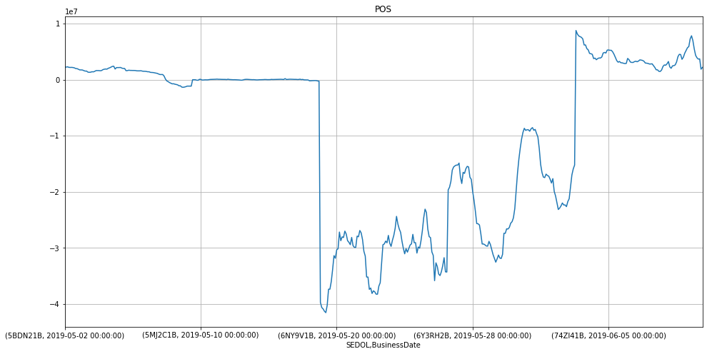

```python
# Visualization of the complete Data
df_grp['Position_Quantity_SD'].plot.line(label='BC', figsize=(16,8), title='POS', grid=True)
```

## 4. Dividing the dataset

Dividing the dataset into 5 different Sedols and performimg the following steps on the resulting dataset.

> - Creating a DataFrame of the SEDOL
> - Grouping the resulting Dataframe according the BusinessDate and adding the Position_Quantity_SD of the same BusinessDates
> - Plotting the graph
> - Creating a window of 30 and dividing the Training and Testing Data
> - Training the model using Linear Regression and plotting the Training and Testing curves (for the first SEDOL - tried different Regression algorithms but didn't see any significant improvements)
> - Applying Simple Moving Average (SMA) using the rolling() function of the Pandas DataFrame with window size = 30 and plotting the graph
> - Applying Exponential Moving Average (EMA) using the ewm() function of the Pandas DataFrame with window size = 30 and plotting the combined graph of SMA and EMA

## SEDOL1

```python
df_sedol1 = df.loc[df.SEDOL=='5BDN21B']
df_sedol1.head()
```

|  | BusinessDate | SEDOL | Counterparty_Account_ID | Position_Quantity_SD |
| --- | --- | --- | --- | --- |
| 0 | 2019-05-02 | 5BDN21B | 11009 | 121000.0 |
| 1 | 2019-05-02 | 5BDN21B | 14120 | 928200.0 |
| 2 | 2019-05-02 | 5BDN21B | 16109 | 1452000.0 |
| 3 | 2019-05-02 | 5BDN21B | 16140 | -40600.0 |
| 4 | 2019-05-02 | 5BDN21B | 62004 | 10000.0 |

```python
df_sedol1_edit = df_sedol1.groupby(['BusinessDate']).sum()
df_sedol1_edit.head()
```

| BusinessDate | Position_Quantity_SD |
| --- | --- |
| 2019-05-02 | 2254208.0 |
| 2019-05-03 | 2249508.0 |
| 2019-05-06 | 2303108.0 |
| 2019-05-07 | 2206708.0 |
| 2019-05-08 | 2188708.0 |

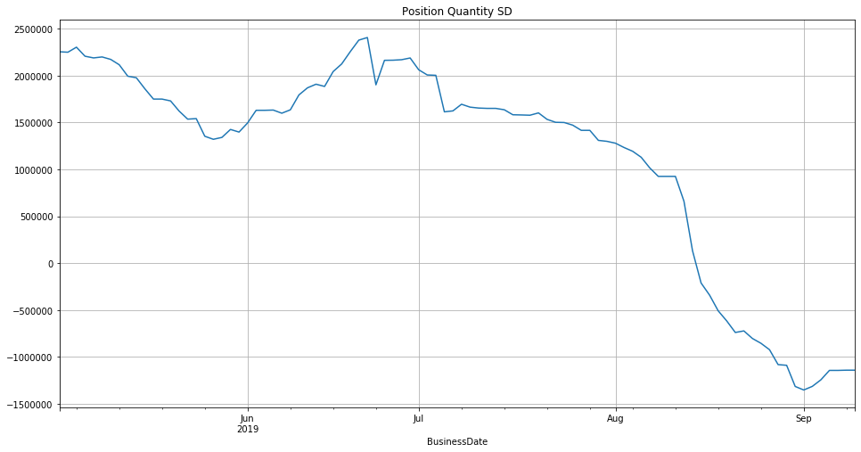

```python
df_sedol1_edit['Position_Quantity_SD'].plot.line(label='SEDOL1', figsize=(16,8), title='Position Quantity SD', grid=True)
```

```python
#Train the model on the last 30 days and predict the label for the 31th day
window = 30

num_samples = len(df_sedol1_edit) - window
indices = np.arange(num_samples).astype(np.int)[:,None] + np.arange(window + 1).astype(np.int)
len(indices)
```

```
64
```

```python
data = df_sedol1_edit['Position_Quantity_SD'].values[indices]
data
```

```
array([[ 2254208.,  2249508.,  2303108., ...,  1793908.,  1869608.,
         1908308.],
       [ 2249508.,  2303108.,  2206708., ...,  1869608.,  1908308.,
         1884608.],
       [ 2303108.,  2206708.,  2188708., ...,  1908308.,  1884608.,
         2043008.],
       ...,
       [ 1416208.,  1416208.,  1309208., ..., -1244092., -1143592.,
        -1143592.],
       [ 1416208.,  1309208.,  1299108., ..., -1143592., -1143592.,
        -1141192.],
       [ 1309208.,  1299108.,  1279008., ..., -1143592., -1141192.,
        -1141192.]])
```

```python
X = data[:, :-1]
y = data[:, -1]
```

```python
split_frac = 0.8
split_indices = int(split_frac * num_samples)
X_train = X[:split_indices]
y_train = y[:split_indices]
X_test = X[split_indices:]
y_test = y[split_indices:]
split_indices
```

```
51
```

```python
#Train
linear_reg_model = LinearRegression()
linear_reg_model.fit(X_train, y_train)

#Inferences
y_pred_train_linear_reg = linear_reg_model.predict(X_train)
y_pred_linear_reg = linear_reg_model.predict(X_test)
```

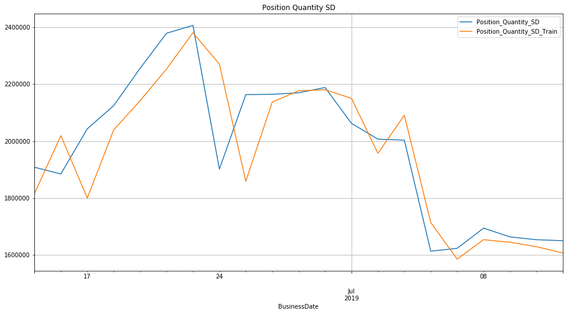

```python
#Plot the graph for it has trained on the training data
df_linear = df_sedol1_edit.copy()
df_linear = df_linear.iloc[window:split_indices]
df_linear['Position_Quantity_SD_Train'] = y_pred_train_linear_reg[:-window]
df_linear.plot(label='SEDOL1', figsize=(16, 8), title='Position Quantity SD', grid=True)
```

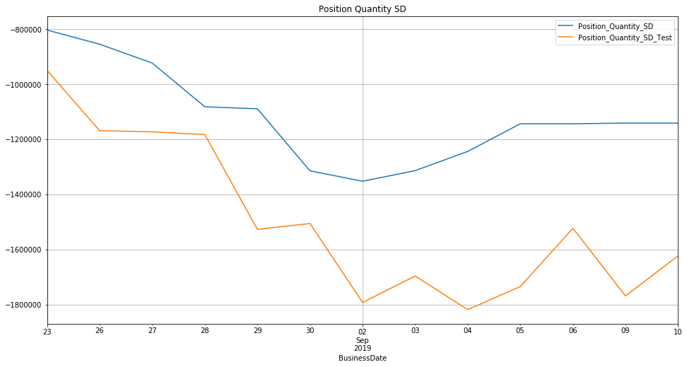

```python
#Plot the graph for the testing data
df_linear = df_sedol1_edit.copy()
df_linear = df_linear.iloc[split_indices+window:]
df_linear['Position_Quantity_SD_Test'] = y_pred_linear_reg
df_linear.plot(label='SEDOL1', figsize=(16, 8), title='Position Quantity SD', grid=True)
```

```python
from sklearn.linear_model import Ridge

#Train
ridge_model = Ridge()
ridge_model.fit(X_train, y_train)

#Inferences
y_pred_train_ridge = ridge_model.predict(X_train)
y_pred_ridge = ridge_model.predict(X_test)
```

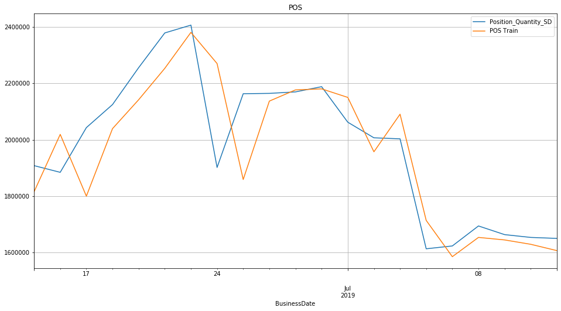

```python
#Plot the graph for it has trained on the training data
df_ridge = df_sedol1_edit.copy()
df_ridge = df_ridge.iloc[window:split_indices]
df_ridge['POS Train'] = y_pred_train_ridge[:-window]
df_ridge.plot(label='SEDOL1', figsize=(16, 8), title='POS', grid=True)
```

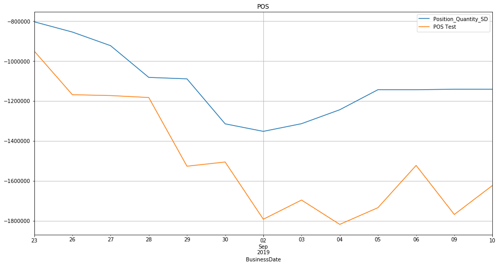

```python
#Plot the graph for the testing data
df_ridge = df_sedol1_edit.copy()
df_ridge = df_ridge.iloc[split_indices+window:]
df_ridge['POS Test'] = y_pred_ridge
df_ridge.plot(label='SEDOL1', figsize=(16, 8), title='POS', grid=True)
```

```python
from sklearn.ensemble import GradientBoostingRegressor

#Train
gb_model = GradientBoostingRegressor()
gb_model.fit(X_train, y_train)

#Inferences
y_pred_train_gb = gb_model.predict(X_train)
y_pred_gb = gb_model.predict(X_test)
```

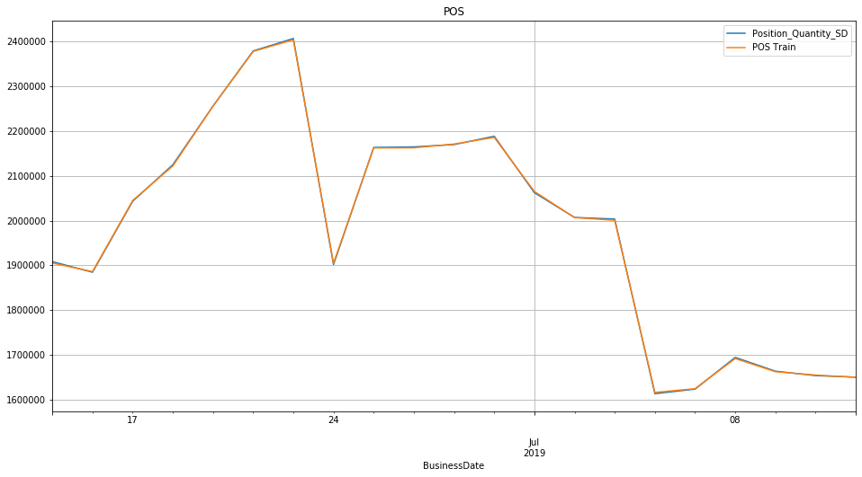

```python
#Plot the graph for it has trained on the training data
df_gb = df_sedol1_edit.copy()
df_gb = df_gb.iloc[window:split_indices]
df_gb['POS Train'] = y_pred_train_gb[:-window]
df_gb.plot(label='SEDOL1', figsize=(16, 8), title='POS', grid=True)
```

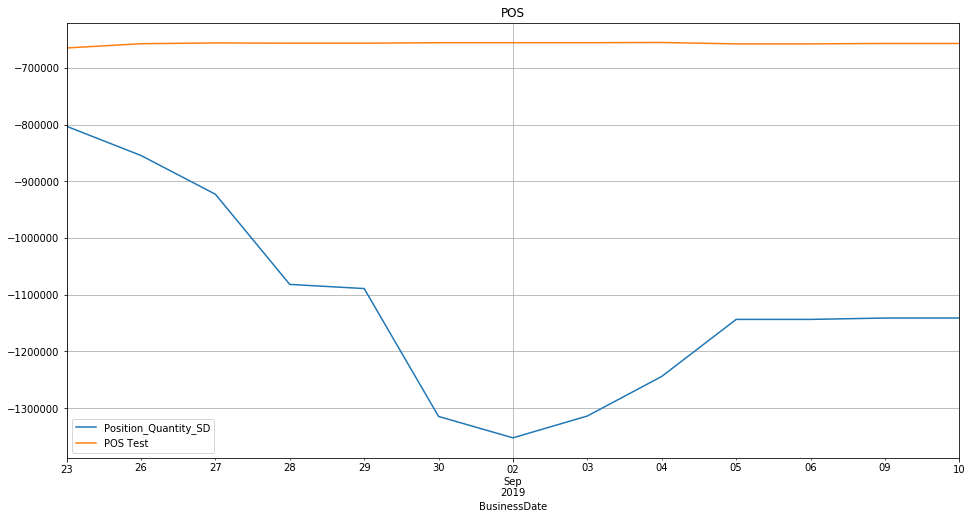

```python
#Plot the graph for the testing data
df_gb = df_sedol1_edit.copy()
df_gb = df_gb.iloc[split_indices+window:]
df_gb['POS Test'] = y_pred_gb
df_gb.plot(label='SEDOL1', figsize=(16, 8), title='POS', grid=True)
```

```python
df_sedol1_edit['SMA(window=30)'] = df_sedol1_edit.Position_Quantity_SD.rolling(window=30).mean()
df_sedol1_edit.tail()
```

| BusinessDate | Position_Quantity_SD | SMA(window=30) |
| --- | --- | --- |
| 2019-09-04 | -1244092.0 | 107194.666667 |
| 2019-09-05 | -1143592.0 | 20021.333333 |
| 2019-09-06 | -1143592.0 | -65305.333333 |
| 2019-09-09 | -1141192.0 | -150552.000000 |
| 2019-09-10 | -1141192.0 | -232232.000000 |

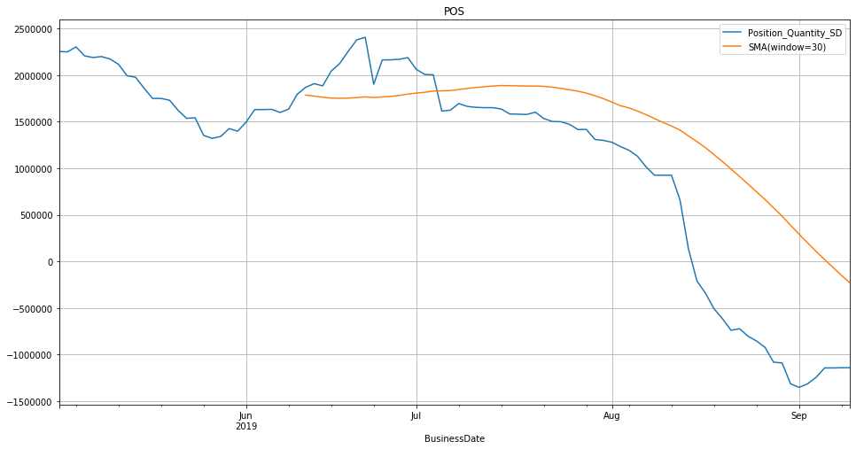

```python
df_sedol1_edit.plot(label='SEDOL1', figsize=(16, 8), title='POS', grid=True)
```

```python
df_sedol1_edit['EMA(window=30)'] = df_sedol1_edit.Position_Quantity_SD.ewm(span=30, adjust=False).mean()
df_sedol1_edit.head()
```

| BusinessDate | Position_Quantity_SD | SMA(window=30) | EMA(window=30) |
| --- | --- | --- | --- |
| 2019-05-02 | 2254208.0 | NaN | 2.254208e+06 |
| 2019-05-03 | 2249508.0 | NaN | 2.253905e+06 |
| 2019-05-06 | 2303108.0 | NaN | 2.257079e+06 |
| 2019-05-07 | 2206708.0 | NaN | 2.253829e+06 |
| 2019-05-08 | 2188708.0 | NaN | 2.249628e+06 |

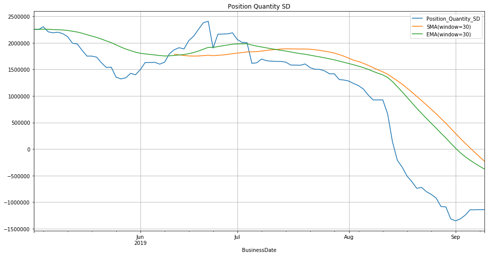

```python
df_sedol1_edit.plot(label='SEDOL1', figsize=(16, 8), title='Position Quantity SD', grid=True)
```

## SEDOL2

```python
df_sedol2 = df.loc[df.SEDOL=='5MJ2C1B']
df_sedol2.head()
```

|  | BusinessDate | SEDOL | Counterparty_Account_ID | Position_Quantity_SD |
| --- | --- | --- | --- | --- |
| 8 | 2019-05-02 | 5MJ2C1B | 0010V | 200.0 |
| 9 | 2019-05-02 | 5MJ2C1B | 1003V | 100.0 |
| 10 | 2019-05-02 | 5MJ2C1B | 12280 | 10000.0 |
| 11 | 2019-05-02 | 5MJ2C1B | 25SJP | -200.0 |
| 12 | 2019-05-02 | 5MJ2C1B | 3210P | -151400.0 |

```python
df_sedol2_edit = df_sedol2.groupby(['BusinessDate']).sum()
df_sedol2_edit.head()
```

| BusinessDate | Position_Quantity_SD |
| --- | --- |
| 2019-05-02 | 732.0 |
| 2019-05-03 | 732.0 |
| 2019-05-06 | -4902.0 |
| 2019-05-07 | -85468.0 |
| 2019-05-08 | -102202.0 |

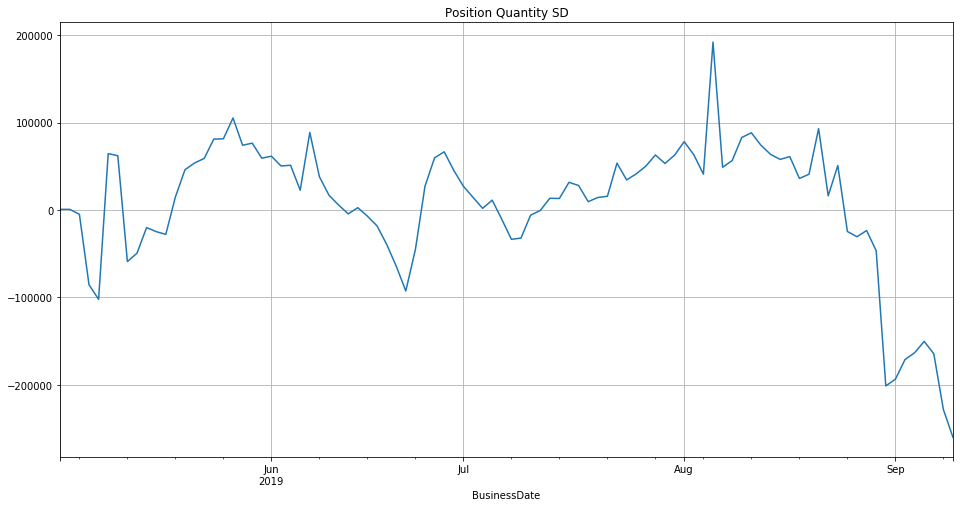

```python
df_sedol2_edit['Position_Quantity_SD'].plot.line(label='SEDOL2', figsize=(16,8), title='Position Quantity SD', grid=True)
```

```python
#Train the model on the last 30 days and predict the label for the 31st day
window = 30

num_samples = len(df_sedol2_edit) - window
indices = np.arange(num_samples).astype(np.int)[:,None] + np.arange(window + 1).astype(np.int)
len(indices)
```

```
64
```

```python
data = df_sedol2_edit['Position_Quantity_SD'].values[indices]
data
```

```
array([[    732.,     732.,   -4902., ...,   16903.,    5703.,   -4402.],
       [    732.,   -4902.,  -85468., ...,    5703.,   -4402.,    2669.],
       [  -4902.,  -85468., -102202., ...,   -4402.,    2669.,   -7031.],
       ...,
       [  50113.,   62928.,   53219., ..., -163315., -150291., -164515.],
       [  62928.,   53219.,   62813., ..., -150291., -164515., -228391.],
       [  53219.,   62813.,   78214., ..., -164515., -228391., -260215.]])
```

```python
X = data[:, :-1]
y = data[:, -1]
```

```python
split_frac = 0.8
split_indices = int(split_frac * num_samples)
X_train = X[:split_indices]
y_train = y[:split_indices]
X_test = X[split_indices:]
y_test = y[split_indices:]
split_indices
```

```
51
```

```python
from sklearn.linear_model import LinearRegression

#Train
linear_reg_model = LinearRegression()
linear_reg_model.fit(X_train, y_train)

#Inferences
y_pred_train_linear_reg = linear_reg_model.predict(X_train)
y_pred_linear_reg = linear_reg_model.predict(X_test)
```

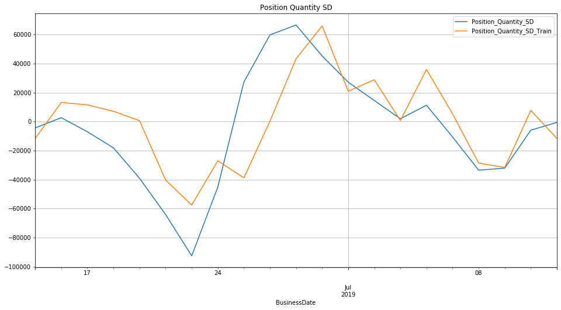

```python
#Plot the graph for it has trained on the training data
df_linear = df_sedol2_edit.copy()
df_linear = df_linear.iloc[window:split_indices]
df_linear['Position_Quantity_SD_Train'] = y_pred_train_linear_reg[:-window]
df_linear.plot(label='SEDOL2', figsize=(16, 8), title='Position Quantity SD', grid=True)
```

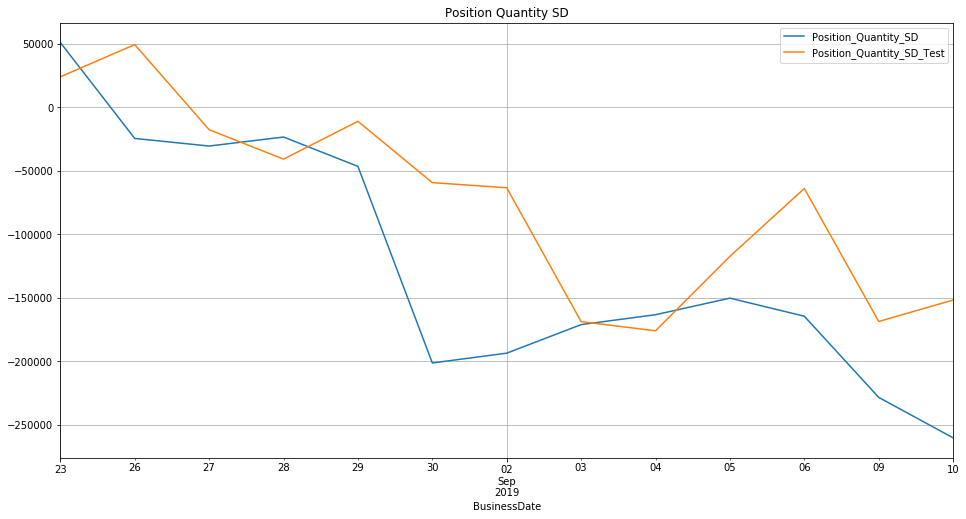

```python
#Plot the graph for the testing data
df_linear = df_sedol2_edit.copy()
df_linear = df_linear.iloc[split_indices+window:]
df_linear['Position_Quantity_SD_Test'] = y_pred_linear_reg
df_linear.plot(label='SEDOL2', figsize=(16, 8), title='Position Quantity SD', grid=True)
```

```python
df_sedol2_edit['SMA(window=30)'] = df_sedol2_edit.Position_Quantity_SD.rolling(window=30).mean()
df_sedol2_edit.tail()
```

| BusinessDate | Position_Quantity_SD | SMA(window=30) |
| --- | --- | --- |
| 2019-09-04 | -163315.0 | 18702.700000 |
| 2019-09-05 | -150291.0 | 12315.900000 |
| 2019-09-06 | -164515.0 | 5161.633333 |
| 2019-09-09 | -228391.0 | -4549.000000 |
| 2019-09-10 | -260215.0 | -14996.800000 |

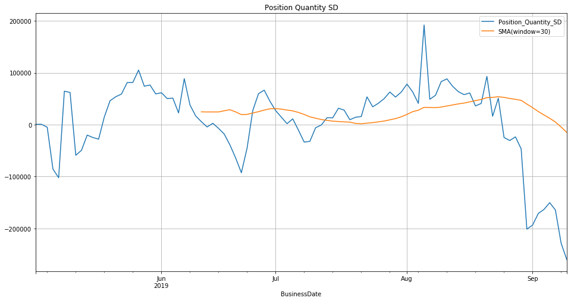

```python
df_sedol2_edit.plot(label='SEDOL2', figsize=(16, 8), title='Position Quantity SD', grid=True)
```

```python
df_sedol2_edit['EMA(window=30)'] = df_sedol2_edit.Position_Quantity_SD.ewm(span=30, adjust=False).mean()
df_sedol2_edit.tail()
```

| BusinessDate | Position_Quantity_SD | SMA(window=30) | EMA(window=30) |
| --- | --- | --- | --- |
| 2019-09-04 | -163315.0 | 18702.700000 | -18221.328766 |
| 2019-09-05 | -150291.0 | 12315.900000 | -26741.952717 |
| 2019-09-06 | -164515.0 | 5161.633333 | -35630.536412 |
| 2019-09-09 | -228391.0 | -4549.000000 | -48066.695354 |
| 2019-09-10 | -260215.0 | -14996.800000 | -61753.682750 |

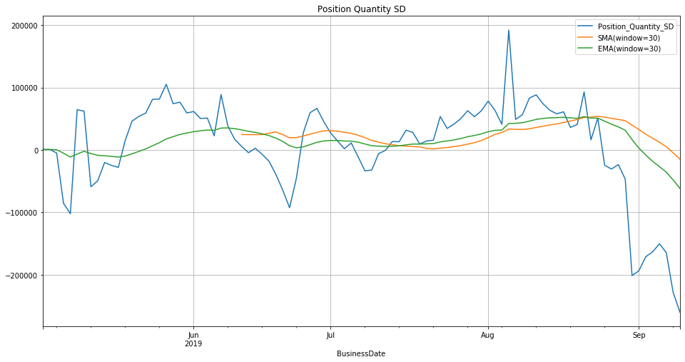

```python
df_sedol2_edit.plot(label='SEDOL2', figsize=(16, 8), title='Position Quantity SD', grid=True)
```

## SEDOL3

```python
df_sedol3 = df.loc[df.SEDOL=='6NY9V1B']
df_sedol3.head()
```

|  | BusinessDate | SEDOL | Counterparty_Account_ID | Position_Quantity_SD |
| --- | --- | --- | --- | --- |
| 32 | 2019-05-02 | 6NY9V1B | 0130V | 346000.0 |
| 33 | 2019-05-02 | 6NY9V1B | 10240 | -511000.0 |
| 34 | 2019-05-02 | 6NY9V1B | 10240 | -3281000.0 |
| 35 | 2019-05-02 | 6NY9V1B | 10321 | 336530.0 |
| 36 | 2019-05-02 | 6NY9V1B | 11009 | 964.0 |

```python
df_sedol3_edit = df_sedol3.groupby(['BusinessDate']).sum()
df_sedol3_edit.head()
```

| BusinessDate | Position_Quantity_SD |
| --- | --- |
| 2019-05-02 | -3.972417e+07 |
| 2019-05-03 | -4.064518e+07 |
| 2019-05-06 | -4.089717e+07 |
| 2019-05-07 | -4.131317e+07 |
| 2019-05-08 | -4.155817e+07 |

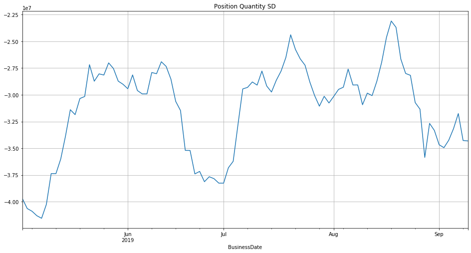

```python
df_sedol3_edit['Position_Quantity_SD'].plot.line(label='SEDOL3', figsize=(16,8), title='Position Quantity SD', grid=True)
```

```python
#Train the model on the last 30 days and predict the label for the 31st day
window = 30

num_samples = len(df_sedol3_edit) - window
indices = np.arange(num_samples).astype(np.int)[:,None] + np.arange(window + 1).astype(np.int)
len(indices)
```

```
64
```

```python
data = df_sedol3_edit['Position_Quantity_SD'].values[indices]
data
```

```
array([[-39724168.        , -40645177.81059113, -40897168.        , ...,
        -28026744.        , -26904744.        , -27339744.        ],
       [-40645177.81059113, -40897168.        , -41313168.        , ...,
        -26904744.        , -27339744.        , -28530744.        ],
       [-40897168.        , -41313168.        , -41558168.        , ...,
        -27339744.        , -28530744.        , -30616744.        ],
       ...,
       [-30067708.        , -31063708.        , -30137708.        , ...,
        -34253708.        , -33168708.        , -31753708.        ],
       [-31063708.        , -30137708.        , -30765708.        , ...,
        -33168708.        , -31753708.        , -34278708.        ],
       [-30137708.        , -30765708.        , -30144708.        , ...,
        -31753708.        , -34278708.        , -34318708.        ]])
```

```python
X = data[:, :-1]
y = data[:, -1]
```

```python
split_frac = 0.8
split_indices = int(split_frac * num_samples)
X_train = X[:split_indices]
y_train = y[:split_indices]
X_test = X[split_indices:]
y_test = y[split_indices:]
split_indices
```

```
51
```

```python
from sklearn.linear_model import LinearRegression

#Train
linear_reg_model = LinearRegression()
linear_reg_model.fit(X_train, y_train)

#Inferences
y_pred_train_linear_reg = linear_reg_model.predict(X_train)
y_pred_linear_reg = linear_reg_model.predict(X_test)
```

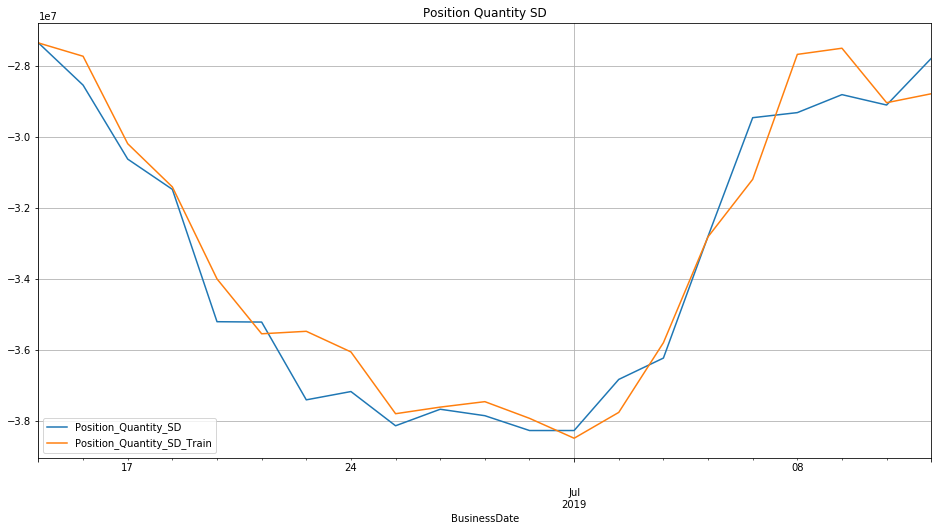

```python
#Plot the graph for it has trained on the training data
df_linear = df_sedol3_edit.copy()
df_linear = df_linear.iloc[window:split_indices]
df_linear['Position_Quantity_SD_Train'] = y_pred_train_linear_reg[:-window]
df_linear.plot(label='SEDOL3', figsize=(16, 8), title='Position Quantity SD', grid=True)
```

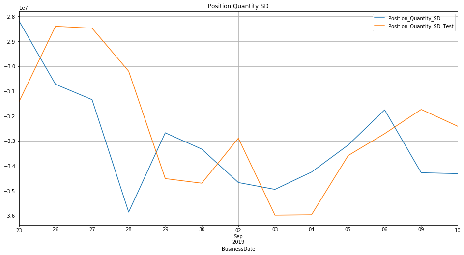

```python
#Plot the graph for the testing data
df_linear = df_sedol3_edit.copy()
df_linear = df_linear.iloc[split_indices+window:]
df_linear['Position_Quantity_SD_Test'] = y_pred_linear_reg
df_linear.plot(label='SEDOL3', figsize=(16, 8), title='Position Quantity SD', grid=True)
```

```python
df_sedol3_edit['SMA(window=30)'] = df_sedol3_edit.Position_Quantity_SD.rolling(window=30).mean()
df_sedol3_edit.tail()
```

| BusinessDate | Position_Quantity_SD | SMA(window=30) |
| --- | --- | --- |
| 2019-09-04 | -34253708.0 | -2.980320e+07 |
| 2019-09-05 | -33168708.0 | -2.994886e+07 |
| 2019-09-06 | -31753708.0 | -3.000506e+07 |
| 2019-09-09 | -34278708.0 | -3.011223e+07 |
| 2019-09-10 | -34318708.0 | -3.025160e+07 |

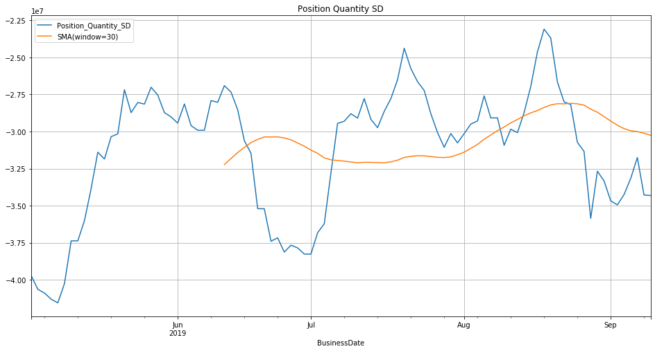

```python
df_sedol3_edit.plot(label='SEDOL3', figsize=(16, 8), title='Position Quantity SD', grid=True)
```

```python
df_sedol3_edit['EMA(window=30)'] = df_sedol3_edit.Position_Quantity_SD.ewm(span=30, adjust=False).mean()
df_sedol3_edit.tail()
```

| BusinessDate | Position_Quantity_SD | SMA(window=30) | EMA(window=30) |
| --- | --- | --- | --- |
| 2019-09-04 | -34253708.0 | -2.980320e+07 | -3.056616e+07 |
| 2019-09-05 | -33168708.0 | -2.994886e+07 | -3.073407e+07 |
| 2019-09-06 | -31753708.0 | -3.000506e+07 | -3.079985e+07 |
| 2019-09-09 | -34278708.0 | -3.011223e+07 | -3.102430e+07 |
| 2019-09-10 | -34318708.0 | -3.025160e+07 | -3.123684e+07 |

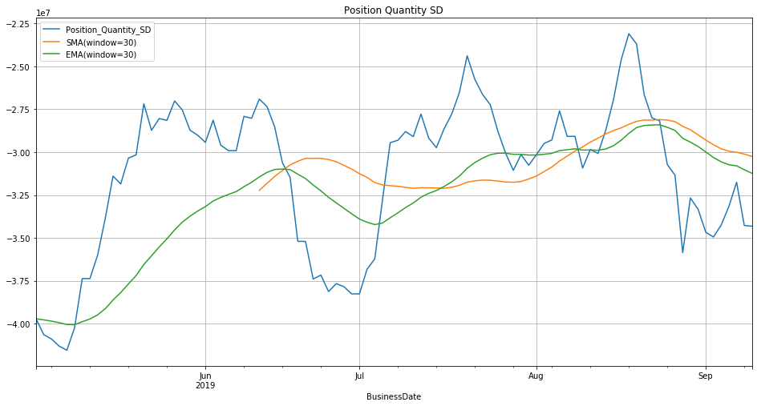

```python
df_sedol3_edit.plot(label='SEDOL3', figsize=(16, 8), title='Position Quantity SD', grid=True)
```

## SEDOL4

```python
df_sedol4 = df.loc[df.SEDOL=='6Y3RH2B']
df_sedol4.head()
```

|  | BusinessDate | SEDOL | Counterparty_Account_ID | Position_Quantity_SD |
| --- | --- | --- | --- | --- |
| 64 | 2019-05-02 | 6Y3RH2B | 10240 | -112000.0 |
| 65 | 2019-05-02 | 6Y3RH2B | 10240 | -373000.0 |
| 66 | 2019-05-02 | 6Y3RH2B | 10321 | 173000.0 |
| 67 | 2019-05-02 | 6Y3RH2B | 1310P | -202000.0 |
| 68 | 2019-05-02 | 6Y3RH2B | 1310V | 520000.0 |

```python
df_sedol4_edit = df_sedol4.groupby(['BusinessDate']).sum()
df_sedol4_edit.head()
```

| BusinessDate | Position_Quantity_SD |
| --- | --- |
| 2019-05-02 | -19662000.0 |
| 2019-05-03 | -19176000.0 |
| 2019-05-06 | -18134000.0 |
| 2019-05-07 | -16142000.0 |
| 2019-05-08 | -15565000.0 |

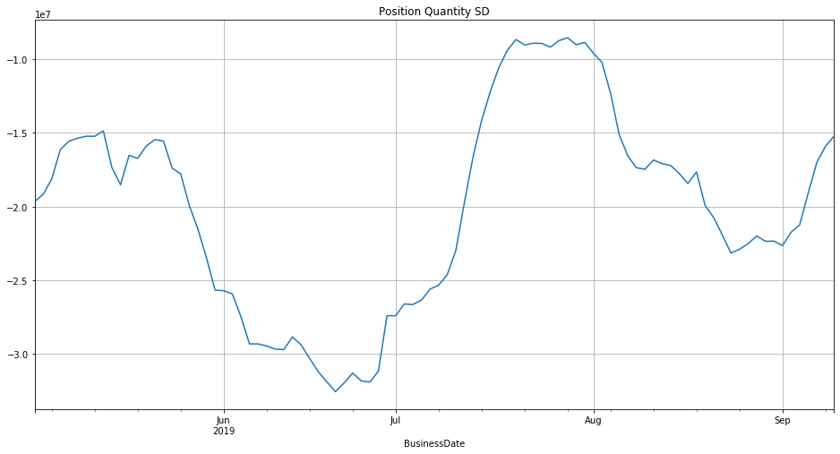

```python
df_sedol4_edit['Position_Quantity_SD'].plot.line(label='SEDOL4', figsize=(16,8), title='Position Quantity SD', grid=True)
```

```python
#Train the model on the last 30 days and predict the label for the 31st day
window = 30

num_samples = len(df_sedol4_edit) - window
indices = np.arange(num_samples).astype(np.int)[:,None] + np.arange(window + 1).astype(np.int)
len(indices)
```

```
64
```

```python
data = df_sedol4_edit['Position_Quantity_SD'].values[indices]
data
```

```
array([[-19662000., -19176000., -18134000., ..., -29666000., -29700000.,
        -28841000.],
       [-19176000., -18134000., -16142000., ..., -29700000., -28841000.,
        -29372000.],
       [-18134000., -16142000., -15565000., ..., -28841000., -29372000.,
        -30296000.],
       ...,
       [ -8747000.,  -8549000.,  -9023000., ..., -21241000., -19065000.,
        -16994000.],
       [ -8549000.,  -9023000.,  -8872000., ..., -19065000., -16994000.,
        -15916000.],
       [ -9023000.,  -8872000.,  -9592000., ..., -16994000., -15916000.,
        -15230000.]])
```

```python
X = data[:, :-1]
y = data[:, -1]
```

```python
split_frac = 0.8
split_indices = int(split_frac * num_samples)
X_train = X[:split_indices]
y_train = y[:split_indices]
X_test = X[split_indices:]
y_test = y[split_indices:]
split_indices
```

```
51
```

```python
from sklearn.linear_model import LinearRegression

#Train
linear_reg_model = LinearRegression()
linear_reg_model.fit(X_train, y_train)

#Inferences
y_pred_train_linear_reg = linear_reg_model.predict(X_train)
y_pred_linear_reg = linear_reg_model.predict(X_test)
```

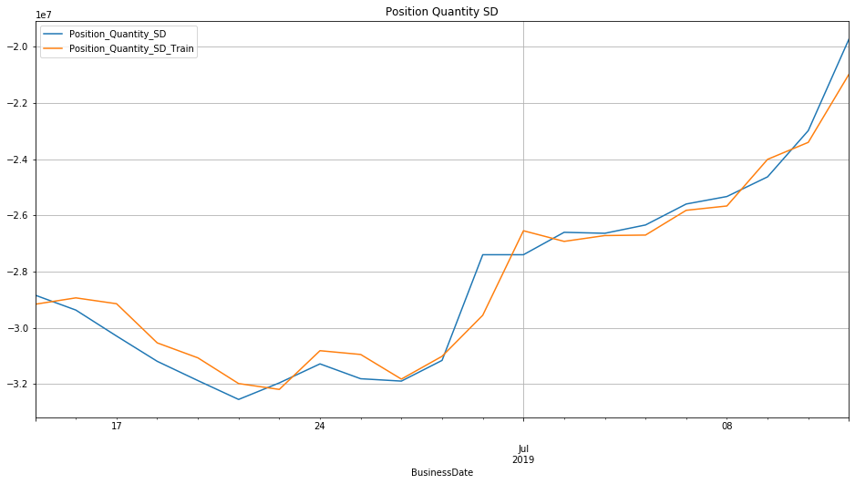

```python
#Plot the graph for it has trained on the training data
df_linear = df_sedol4_edit.copy()
df_linear = df_linear.iloc[window:split_indices]
df_linear['Position_Quantity_SD_Train'] = y_pred_train_linear_reg[:-window]
df_linear.plot(label='SEDOL4', figsize=(16, 8), title='Position Quantity SD', grid=True)
```

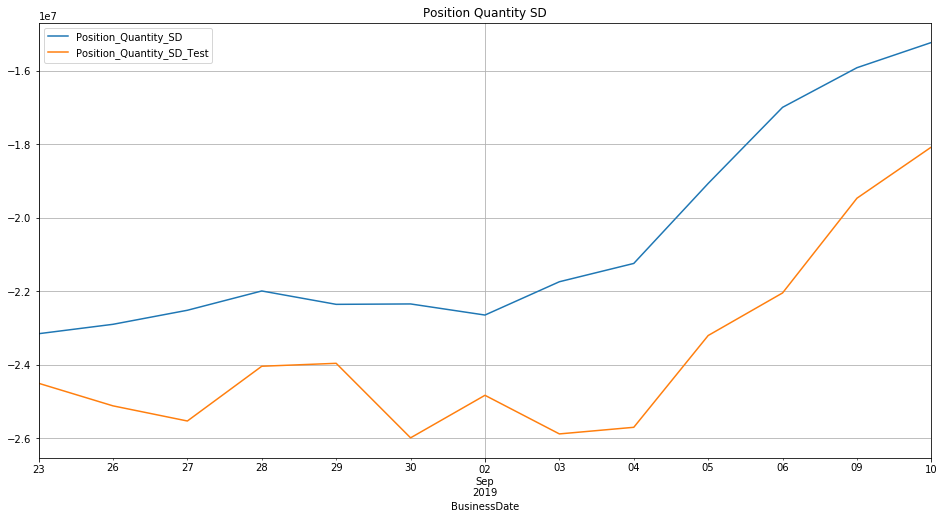

```python
#Plot the graph for testing data
df_linear = df_sedol4_edit.copy()
df_linear = df_linear.iloc[split_indices+window:]
df_linear['Position_Quantity_SD_Test'] = y_pred_linear_reg
df_linear.plot(label='SEDOL4', figsize=(16, 8), title='Position Quantity SD', grid=True)
```

```python
df_sedol4_edit['SMA(window=30)'] = df_sedol4_edit.Position_Quantity_SD.rolling(window=30).mean()
df_sedol4_edit.tail()
```

| BusinessDate | Position_Quantity_SD | SMA(window=30) |
| --- | --- | --- |
| 2019-09-04 | -21241000.0 | -1.704940e+07 |
| 2019-09-05 | -19065000.0 | -1.737863e+07 |
| 2019-09-06 | -16994000.0 | -1.765353e+07 |
| 2019-09-09 | -15916000.0 | -1.789910e+07 |
| 2019-09-10 | -15230000.0 | -1.810600e+07 |

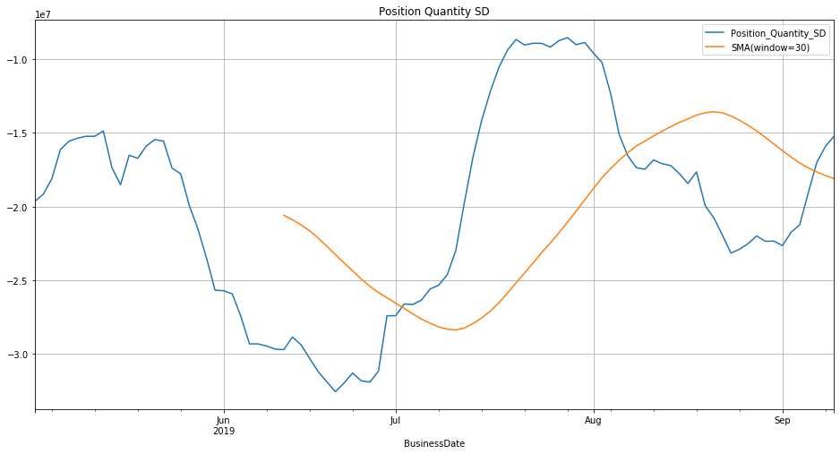

```python
df_sedol4_edit.plot(label='SEDOL4', figsize=(16, 8), title='Position Quantity SD', grid=True)
```

```python
df_sedol4_edit['EMA(window=30)'] = df_sedol4_edit.Position_Quantity_SD.ewm(span=30, adjust=False).mean()
df_sedol4_edit.tail()
```

| BusinessDate | Position_Quantity_SD | SMA(window=30) | EMA(window=30) |
| --- | --- | --- | --- |
| 2019-09-04 | -21241000.0 | -1.704940e+07 | -1.939856e+07 |
| 2019-09-05 | -19065000.0 | -1.737863e+07 | -1.937704e+07 |
| 2019-09-06 | -16994000.0 | -1.765353e+07 | -1.922329e+07 |
| 2019-09-09 | -15916000.0 | -1.789910e+07 | -1.900992e+07 |
| 2019-09-10 | -15230000.0 | -1.810600e+07 | -1.876605e+07 |

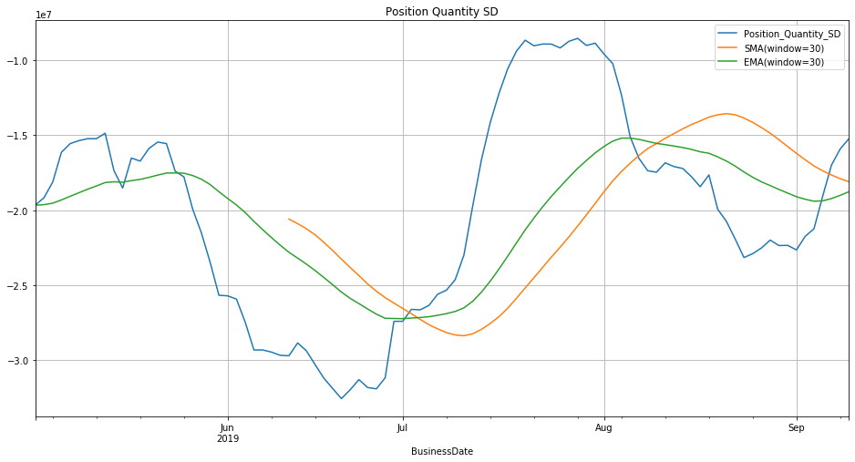

```python
df_sedol4_edit.plot(label='SEDOL4', figsize=(16, 8), title='Position Quantity SD', grid=True)
```

## SEDOL5

```python
df_sedol5 = df.loc[df.SEDOL=='74ZI41B']
df_sedol5.head()
```

|  | BusinessDate | SEDOL | Counterparty_Account_ID | Position_Quantity_SD |
| --- | --- | --- | --- | --- |
| 87 | 2019-05-02 | 74ZI41B | 1003V | 697000.0 |
| 88 | 2019-05-02 | 74ZI41B | 10240 | 4000.0 |
| 89 | 2019-05-02 | 74ZI41B | 10240 | 557000.0 |
| 90 | 2019-05-02 | 74ZI41B | 10321 | 433000.0 |
| 91 | 2019-05-02 | 74ZI41B | 12210 | 164000.0 |

```python
df_sedol5_edit = df_sedol5.groupby(['BusinessDate']).sum()
df_sedol5_edit.head()
```

| BusinessDate | Position_Quantity_SD |
| --- | --- |
| 2019-05-02 | 8785907.0 |
| 2019-05-03 | 8177907.0 |
| 2019-05-06 | 7815907.0 |
| 2019-05-07 | 7686907.0 |
| 2019-05-08 | 7561907.0 |

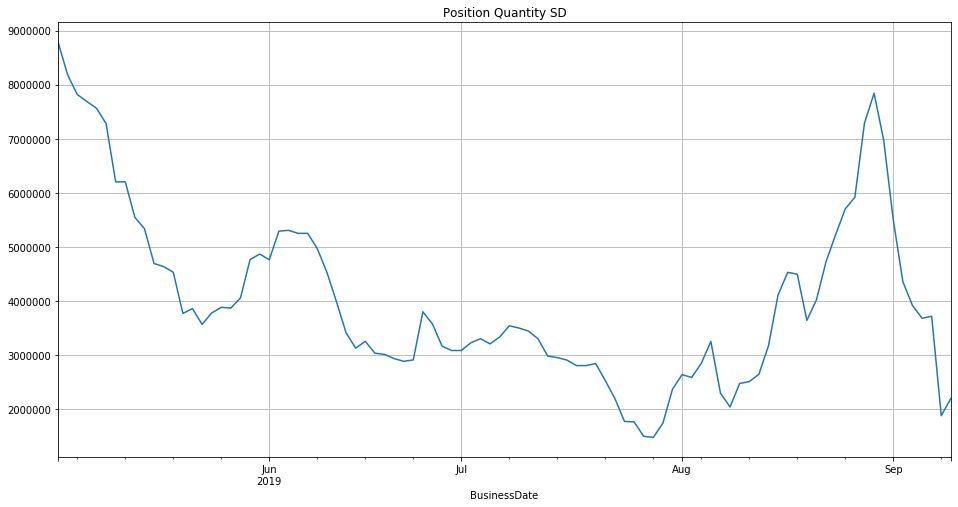

```python
df_sedol5_edit['Position_Quantity_SD'].plot.line(label='SEDOL5', figsize=(16,8), title='Position Quantity SD', grid=True)
```

```python
#Train the model on the last 30 days and predict the label for the 31st day
window = 30

num_samples = len(df_sedol5_edit) - window
indices = np.arange(num_samples).astype(np.int)[:,None] + np.arange(window + 1).astype(np.int)
len(indices)
```

```
64
```

```python
data = df_sedol5_edit['Position_Quantity_SD'].values[indices]
data
```

```
array([[8785907., 8177907., 7815907., ..., 4529907., 3982907., 3407907.],
       [8177907., 7815907., 7686907., ..., 3982907., 3407907., 3123907.],
       [7815907., 7686907., 7561907., ..., 3407907., 3123907., 3250907.],
       ...,
       [1493907., 1472907., 1735907., ..., 3913907., 3677907., 3713907.],
       [1472907., 1735907., 2364907., ..., 3677907., 3713907., 1874907.],
       [1735907., 2364907., 2634907., ..., 3713907., 1874907., 2195907.]])
```

```python
X = data[:, :-1]
y = data[:, -1]
```

```python
split_frac = 0.8
split_indices = int(split_frac * num_samples)
X_train = X[:split_indices]
y_train = y[:split_indices]
X_test = X[split_indices:]
y_test = y[split_indices:]
split_indices
```

```
51
```

```python
from sklearn.linear_model import LinearRegression

#Train
linear_reg_model = LinearRegression()
linear_reg_model.fit(X_train, y_train)

#Inferences
y_pred_train_linear_reg = linear_reg_model.predict(X_train)
y_pred_linear_reg = linear_reg_model.predict(X_test)
```

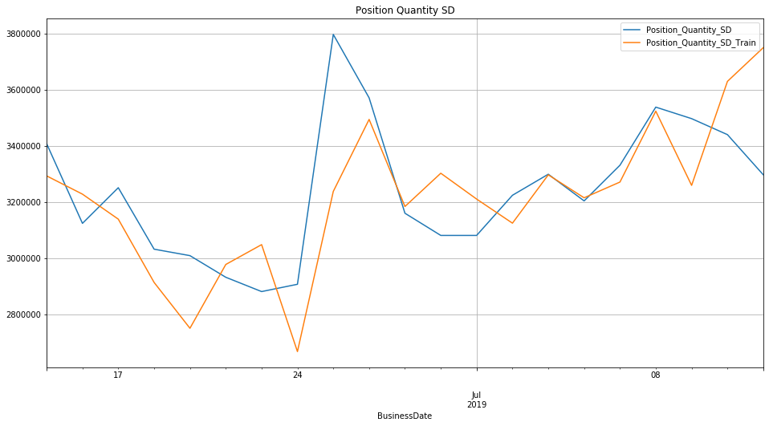

```python
#Plot the graph for it has trained on the training data
df_linear = df_sedol5_edit.copy()
df_linear = df_linear.iloc[window:split_indices]
df_linear['Position_Quantity_SD_Train'] = y_pred_train_linear_reg[:-window]
df_linear.plot(label='SEDOL5', figsize=(16, 8), title='Position Quantity SD', grid=True)
```

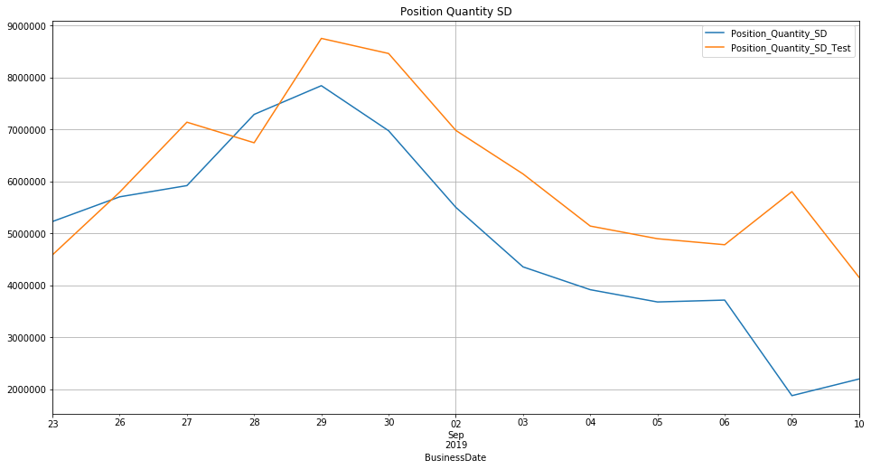

```python
#Plot the graph for the testing data
df_linear = df_sedol5_edit.copy()
df_linear = df_linear.iloc[split_indices+window:]
df_linear['Position_Quantity_SD_Test'] = y_pred_linear_reg
df_linear.plot(label='SEDOL5', figsize=(16, 8), title='Position Quantity SD', grid=True)
```

```python
df_sedol5_edit['SMA(window=30)'] = df_sedol5_edit.Position_Quantity_SD.rolling(window=30).mean()
df_sedol5_edit.tail()
```

| BusinessDate | Position_Quantity_SD | SMA(window=30) |
| --- | --- | --- |
| 2019-09-04 | 3913907.0 | 3.782407e+06 |
| 2019-09-05 | 3677907.0 | 3.846307e+06 |
| 2019-09-06 | 3713907.0 | 3.920307e+06 |
| 2019-09-09 | 1874907.0 | 3.933707e+06 |
| 2019-09-10 | 2195907.0 | 3.949040e+06 |

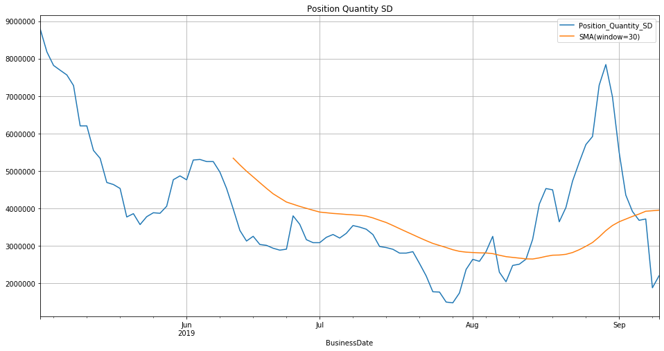

```python
df_sedol5_edit.plot(label='SEDOL5', figsize=(16, 8), title='Position Quantity SD', grid=True)
```

```python
df_sedol5_edit['EMA(window=30)'] = df_sedol5_edit.Position_Quantity_SD.ewm(span=30, adjust=False).mean()
df_sedol5_edit.tail()
```

| BusinessDate | Position_Quantity_SD | SMA(window=30) | EMA(window=30) |
| --- | --- | --- | --- |
| 2019-09-04 | 3913907.0 | 3.782407e+06 | 4.382346e+06 |
| 2019-09-05 | 3677907.0 | 3.846307e+06 | 4.336899e+06 |
| 2019-09-06 | 3713907.0 | 3.920307e+06 | 4.296706e+06 |
| 2019-09-09 | 1874907.0 | 3.933707e+06 | 4.140461e+06 |
| 2019-09-10 | 2195907.0 | 3.949040e+06 | 4.015006e+06 |

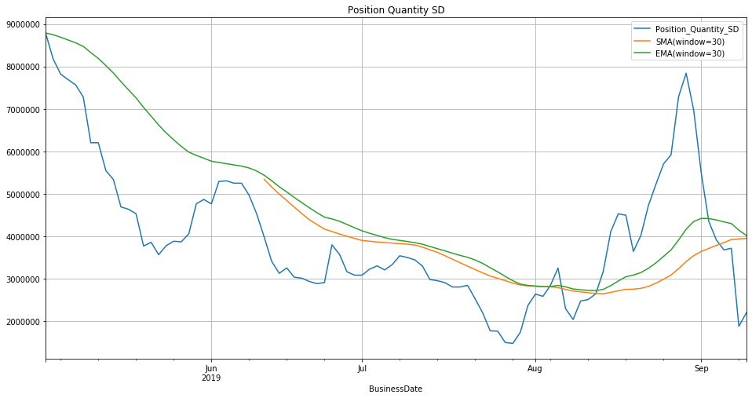

```python
df_sedol5_edit.plot(label='SEDOL5', figsize=(16, 8), title='Position Quantity SD', grid=True)
```